# Assignment 6: Analysis of longitudinal data

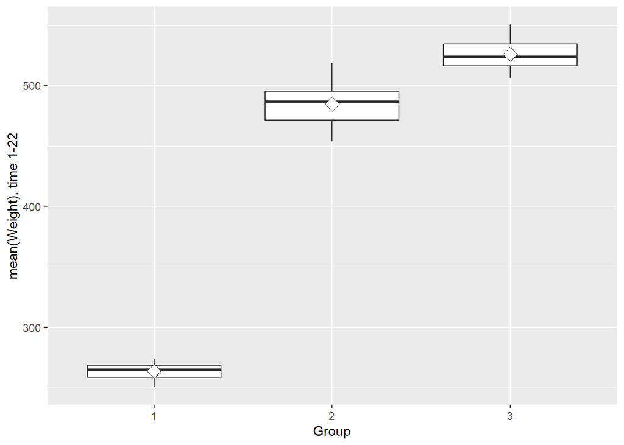

```r
library(ggplot2)
ggplot(Rats_mean, aes(x = Group, y = mean)) +
  geom_boxplot() +
  stat_summary(fun = "mean", geom = "point", shape=23, size=4, fill = "white") +
  scale_y_continuous(name = "mean(Weight), time 1-22")
```

- Again G1 plays it’s own games, with clearly lower mean weight and less variation than in the other groups.
- G2 shows the most variance in weights within the group, while G3 has overall highest mean weight.
- No outliers identifiable.
4. Statistical testing
- Here, we do not have baseline data (Time = 0). Measurements start at t=1.
- As there are now 3 groups of rats, a 2-sample t test will not be a feasible tool. It can deal with 2 groups, but no more than that.
- As such we will have go straight to anova.

```r
# Fit the linear model with the mean as the response
fit <- lm(mean ~ Group, data = Rats_mean)
anova(fit)
```

```
## Analysis of Variance Table
##
## Response: mean
##           Df Sum Sq Mean Sq F value    Pr(>F)
## Group      2 437104  218552  1006.3 < 2.2e-16 ***
## Residuals 30   6516     217
## ---
## Signif. codes:  0 '***' 0.001 '**' 0.01 '*' 0.05 '.' 0.1 ' ' 1
```

- ANOVA detects a statistically significant (P < 0001) difference in weight of rats between treatment groups.
- Let’s see if the same can be said the distinctly different G1 is omitted. Do only 2 and 3 differ enough for anova to detect a difference?

```r
Rats_mean_filtered<-filter(Rats_mean, Group %in% c(2,3))
# Fit the linear model with the mean as the response
fit <- lm(mean ~ Group, data = Rats_mean_filtered)
anova(fit)
```

```
## Analysis of Variance Table
##
## Response: mean
##           Df Sum Sq Mean Sq F value    Pr(>F)
## Group      1 9286.5  9286.5  31.192 1.819e-05 ***
## Residuals 20 5954.5   297.7
## ---
## Signif. codes:  0 '***' 0.001 '**' 0.01 '*' 0.05 '.' 0.1 ' ' 1
```

*Looks like the difference between G2 and G3 is still large enough that a statistically significant difference can be seen.

### Task 2: Implement the analyses of Chapter 9 of MABS, using the R codes of Exercise Set 6: Meet and Repeat: PART II, but using the BPRS data (from Chapter 8 and Meet and Repeat: PART I).

(0-8 points: 0-4 points for graphs or analysis results + 0-4 points for their interpretations)

1. Load the long-form BPRS data created in the wrangling script

```r
library(readr)
BPRS_lng <- read_csv(here("Data/BPRS_lng.csv"))
```

```
## ──────────────────────────────────────────────────────── Delimiter: "," chr
## (1): weeks dbl (5): ...1, treatment, subject, pbrs, Week
```

```r
BPRS_lng$...1<-NULL

#Re-factorize the treatment var
BPRS_lng$treatment<-as.factor(BPRS_lng$treatment)
```

2. Statistical analysis.
- First, we fit the BPRS data with a random intercept model. This differs from regular lm-function linear regressions in that each test subject in the data can have different regression slope intercept points than the rest.
- Moreover, the model does not assume that the observations (here taken from the same patients over time) are independent.
- We seek to explain the PBRS score with treatment group and time. Subject ID is chosen as the random effect, varying from individual to individual. Treatment and time are the fixed effects.

```r
library(lme4)
# Create a random intercept model
BPRS_RandomInt <- lmer(pbrs ~ Week + treatment + (1 | subject), data = BPRS_lng, REML = FALSE)

# Print the summary of the model

summary(BPRS_RandomInt)
```

```
## Linear mixed model fit by maximum likelihood  ['lmerMod']
## Formula: pbrs ~ Week + treatment + (1 | subject)
##    Data: BPRS_lng
##
##      AIC      BIC   logLik deviance df.resid
##   2748.7   2768.1  -1369.4   2738.7      355
##
## Scaled residuals:
##     Min      1Q  Median      3Q     Max
## -3.0481 -0.6749 -0.1361  0.4813  3.4855
##
## Random effects:
##  Groups   Name        Variance Std.Dev.
##  subject  (Intercept)  47.41    6.885
##  Residual             104.21   10.208
## Number of obs: 360, groups:  subject, 20
##
## Fixed effects:
##             Estimate Std. Error t value
## (Intercept)  46.4539     1.9090  24.334
## Week         -2.2704     0.2084 -10.896
## treatment2    0.5722     1.0761   0.532
##
## Correlation of Fixed Effects:
##            (Intr) Week
## Week       -0.437
## treatment2 -0.282  0.000
```

```r
anova(BPRS_RandomInt)
```

```
## Analysis of Variance Table
##           npar  Sum Sq Mean Sq  F value
## Week         1 12371.5 12371.5 118.7136
## treatment    1    29.5    29.5   0.2828
```

```r
library(lme4)

BPRS_int_coeff<-lmer(pbrs ~ Week + treatment + (Week | subject), data = BPRS_lng, REML = FALSE)

# print a summary of the model

summary(BPRS_int_coeff)
```

```
## Linear mixed model fit by maximum likelihood  ['lmerMod']
## Formula: pbrs ~ Week + treatment + (Week | subject)
##    Data: BPRS_lng
##
##      AIC      BIC   logLik deviance df.resid
##   2745.4   2772.6  -1365.7   2731.4      353
##
## Scaled residuals:
##     Min      1Q  Median      3Q     Max
## -2.8919 -0.6194 -0.0691  0.5531  3.7976
##
## Random effects:
##  Groups   Name        Variance Std.Dev. Corr
##  subject  (Intercept) 64.8222  8.0512
##           Week         0.9609  0.9802   -0.51
##  Residual             97.4305  9.8707
## Number of obs: 360, groups:  subject, 20
##
## Fixed effects:
##             Estimate Std. Error t value
## (Intercept)  46.4539     2.1052  22.066
## Week         -2.2704     0.2977  -7.626
## treatment2    0.5722     1.0405   0.550
##
## Correlation of Fixed Effects:
##            (Intr) Week
## Week       -0.582
## treatment2 -0.247  0.000
```

```r
# perform an ANOVA test on the two models
anova(BPRS_int_coeff)
```

```
## Analysis of Variance Table
##           npar Sum Sq Mean Sq F value
## Week         1 5666.0  5666.0 58.1540
## treatment    1   29.5    29.5  0.3025
```

- AIC decreases to 2745 -> Better fit than the previous model, in which just the intercepts were allowed to vary between individuals.
- Considerable increase in the variance of random effects (between-individual variation strong regarding both intercepts and slopes).
- Regarding fixed effects, the coefficient directions appear unchanged.
- Interaction model

*Next, we add an interaction variable: week x treatment.

```r
library(lme4)

Interaction<-lmer(pbrs ~ Week + treatment + (Week | subject)+Week*treatment, data = BPRS_lng, REML = FALSE)

# print a summary of the model

summary(Interaction)
```

```
## Linear mixed model fit by maximum likelihood  ['lmerMod']
## Formula: pbrs ~ Week + treatment + (Week | subject) + Week * treatment
##    Data: BPRS_lng
##
##      AIC      BIC   logLik deviance df.resid
##   2744.3   2775.4  -1364.1   2728.3      352
##
## Scaled residuals:
##     Min      1Q  Median      3Q     Max
## -3.0513 -0.6271 -0.0768  0.5288  3.9260
##
## Random effects:
##  Groups   Name        Variance Std.Dev. Corr
##  subject  (Intercept) 65.0048  8.0626
##           Week         0.9687  0.9842   -0.51
##  Residual             96.4702  9.8219
## Number of obs: 360, groups:  subject, 20
##
## Fixed effects:
##                 Estimate Std. Error t value
## (Intercept)      47.8856     2.2522  21.262
## Week             -2.6283     0.3589  -7.323
## treatment2       -2.2911     1.9090  -1.200
## Week:treatment2   0.7158     0.4010   1.785
##
## Correlation of Fixed Effects:
##             (Intr) Week   trtmn2
## Week        -0.650
## treatment2  -0.424  0.469
## Wek:trtmnt2  0.356 -0.559 -0.840
```

```r
# perform an ANOVA test on the two models
anova(Interaction)
```

```
## Analysis of Variance Table
##                npar Sum Sq Mean Sq F value
## Week              1 5610.7  5610.7 58.1598
## treatment         1   29.5    29.5  0.3055
## Week:treatment    1  307.5   307.5  3.1870
```

- AIC decreases even further, indicating that the model fits the data better with the interaction than without it.
- Final anova on all 3 candidate models

```r
anova(Interaction,BPRS_int_coeff,BPRS_RandomInt)
```

```
## Data: BPRS_lng
## Models:
## BPRS_RandomInt: pbrs ~ Week + treatment + (1 | subject)
## BPRS_int_coeff: pbrs ~ Week + treatment + (Week | subject)
## Interaction: pbrs ~ Week + treatment + (Week | subject) + Week * treatment
##                npar    AIC    BIC  logLik deviance  Chisq Df Pr(>Chisq)
## BPRS_RandomInt    5 2748.7 2768.1 -1369.4   2738.7
## BPRS_int_coeff    7 2745.4 2772.6 -1365.7   2731.4 7.2721  2    0.02636 *
## Interaction       8 2744.3 2775.4 -1364.1   2728.3 3.1712  1    0.07495 .
## ---
## Signif. codes:  0 '***' 0.001 '**' 0.01 '*' 0.05 '.' 0.1 ' ' 1
```